# UEA UCU COVID-19 Member Survey

[figure not shown]

As mandated by members during our last Extraordinary General Meeting, the UEA UCU Committee has created a brief, anonymous survey to collate member experiences and feedback and ensure this informs our ongoing discussions with management.

This survey currently has **168 responses** with the last addition at **2020-10-07 17:00:34**.

This script was last run on **2020-10-11**.

## Question 1 - What department are you based in?

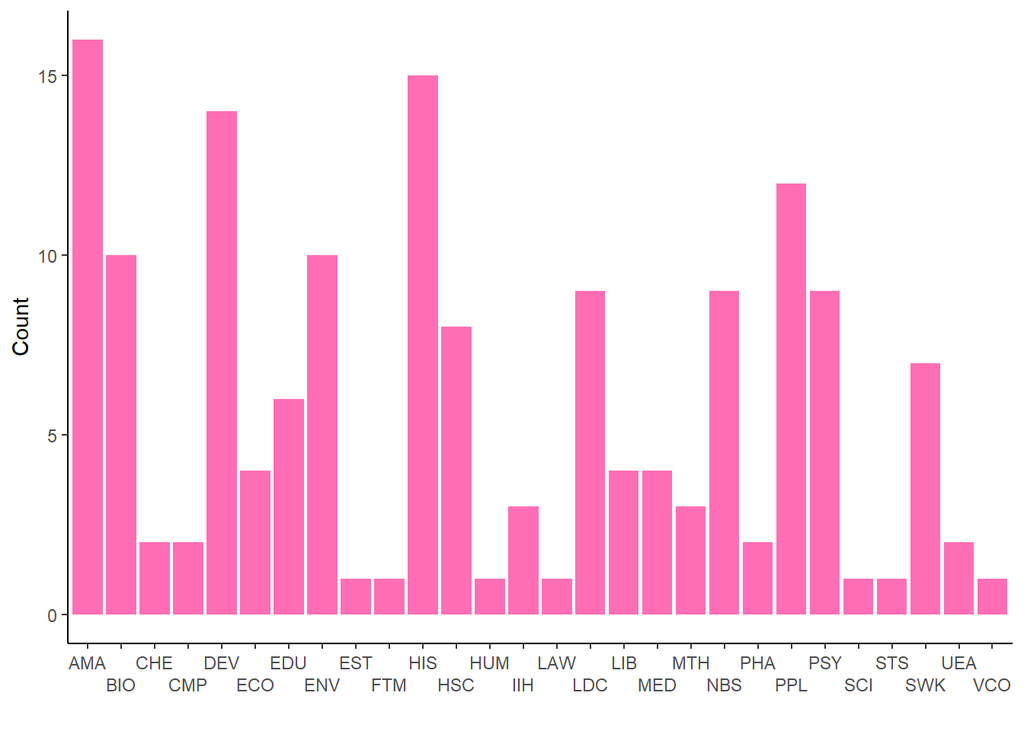

## Question 2 - Would you class yourself, or those in your household, as moderate risk or high risk from COVID-19?

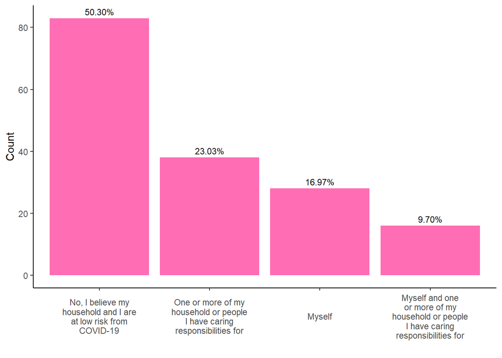

## Question 5 - Have you undertaken any face-to-face learning activities so far this term?

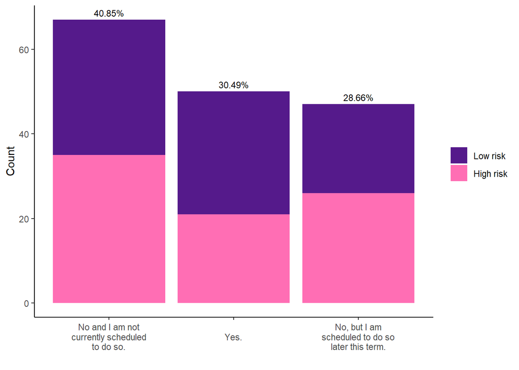

## Question 7 - How satisfied are you with the training and support available to staff to aid “blended” or fully online learning approaches?

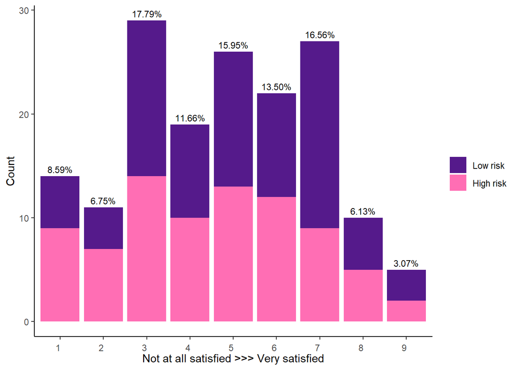

## Questions 9:13 - How strongly do you agree with the following statements?

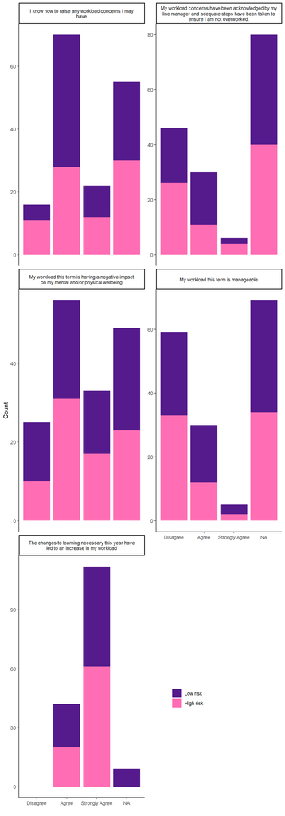

## Questions 14 - Which of the following statements match your feelings about face-to-face learning activities? (Tick all that apply)

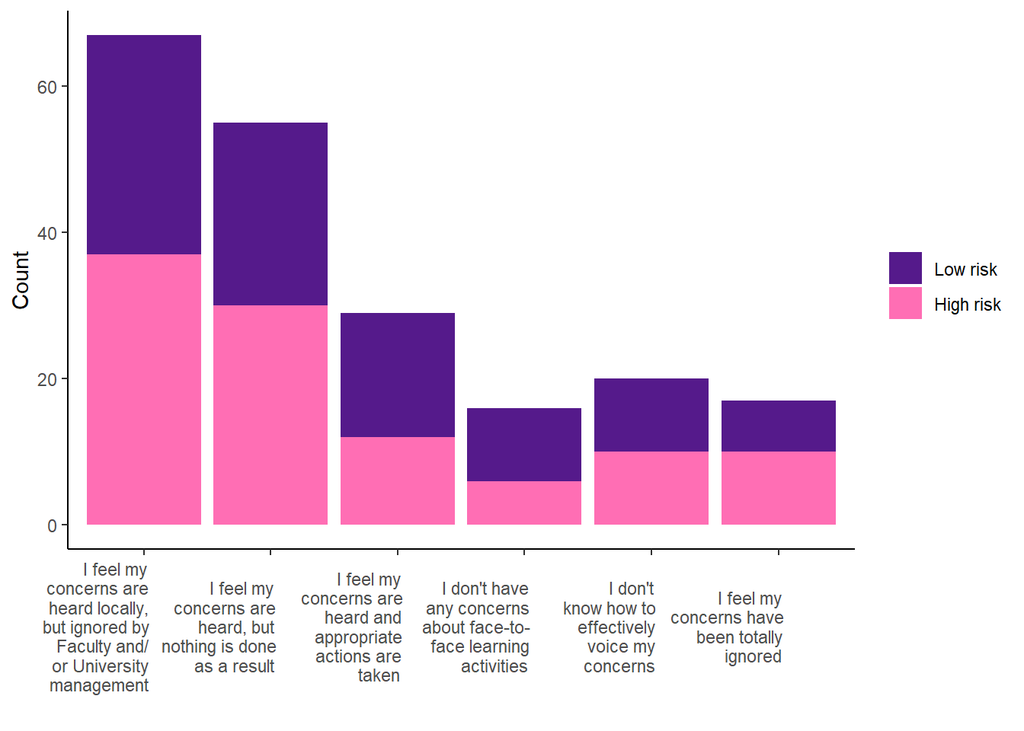

## Comments

#### N.B. responses have been shared only when permission was granted to do so

[output not shown]

## Simple stats tests

A simple ANOVA of self-declared risk level to COVID-19 as a predictor of responses to the question “How satisfied are you with the resumption of face-to-face learning activities?”

|  | Df | Sum Sq | Mean Sq | F value | Pr(>F) |
| --- | --- | --- | --- | --- | --- |
| dd[[3]] | 3 | 39.85 | 13.28 | 2.53 | 0.06 |
| Residuals | 160 | 838.51 | 5.24 | NA | NA |